# Homework 5

Jun Ryu

2023-03-23

```r
knitr::opts_chunk$set(echo = TRUE)
source("605574052_stats102a_hw5.R")
```

## Question 1

### (1)

The following is the code for the bisection method:

```r
bisection <- function(f, a, b, tol) {
  iter <- 0
  while (b-a > tol) {
    mid <- (a+b)/2
    f_mid <- f(mid)
    if (identical(all.equal(f_mid,0),TRUE)) {
      break
    }

    if(f(a)*f_mid < 0) {
      b <- mid
    } else {
      a <- mid
    }

    iter <- iter + 1
  }

  print(mid)
  print(iter)
}
```

#### (a)

Here, I will use -4 and -2 as endpoints because f(-4) < 0 and f(-2) > 0, meaning f(-4)*f(-2) < 0 and the bound will contain a root inside. After running the code, we see that the number of iterations required to meet desired tolerance is 28.

```r
f <- function(x) {
  x^3+23
}

bisection(f,-4,-2,10^-8)
```

```
## [1] -2.843867
## [1] 28
```

#### (b)

Here, I will use 2 and 4 as endpoints because f(2) < 0 and f(4) > 0, meaning f(2)*f(4) < 0 and the bound will contain a root inside. After running the code, we see that the number of iterations required to meet desired tolerance is 28.

```r
g <- function(x) {
  x^x-18
}

bisection(g,2,4,10^-8)
```

```
## [1] 2.803663
## [1] 28
```

#### (c)

Here, I will use 0 and 2 as endpoints because f(0) > 0 and f(2) < 0, meaning f(0)*f(2) < 0 and the bound will contain a root inside. After running the code, we see that the number of iterations required to meet desired tolerance is 23.

```r
h <- function(x) {
  exp(1)^-(x^2)-(1/10)
}

bisection(h,0,2,10^-8)
```

```
## [1] 1.517427
## [1] 23
```

However, this function actually possesses a second root, so we run the function again with -2 and 0 as our endpoints. We observe the same number of iterations to converge and our root is the negative of the one above.

```r
bisection(h,-2,0,10^-8)
```

```
## [1] -1.517427
## [1] 23
```

### (2)

The following is the code for the fixed point method:

```r
fixed_point <- function(f, a, tol) {
  a_new <- f(a)
  iter <- 0
  while(abs(a_new-a) > tol) {
    a <- a_new
    a_new <- f(a)
    iter <- iter + 1
  }

  print(a_new)
  print(iter)
}
```

```r
g <- function(x) {
  log(18)/log(x)
}

fixed_point(g, 2, 10^-8)
```

```
## [1] 2.803663
## [1] 636
```

### (3)

#### **`get_sqrt()`**

**Algorithm:**

1. Error check by making sure the input a is not a negative number.
2. Initialize the iteration count and the initial value.
3. Define f(x) to be x^2-a, since setting this equal to 0 and solving for x will result in the square root of a.
4. Compute f’(x) and define it.
5. Now, run the Newton’s method for approximating a root and per each iteration, have the iteration count increase by 1.
6. If iteration count reaches above iter_max, throw an error.
7. If verbose is set to TRUE, calculate the error and print the iteration count, approximation, and the error at each step of the while loop.
8. If verbose is set to FALSE, print the final approximation and the final iteration count.

#### (b)

```r
get_sqrt(5)
```

```
## [1] "The square root is 2.23606797749998 found in 5 iterations."
```

```r
get_sqrt(5, verbose=T)
```

```
## [1] "After 1 iterations, the approximation is at 3 with an error of 0.76393202250021"
## [1] "After 2 iterations, the approximation is at 2.33333333333333 with an error of 0.0972653558335437"
## [1] "After 3 iterations, the approximation is at 2.23809523809524 with an error of 0.00202726059544833"
## [1] "After 4 iterations, the approximation is at 2.23606889564336 with an error of 9.18143573613861e-07"
## [1] "After 5 iterations, the approximation is at 2.23606797749998 with an error of 1.88293824976427e-13"
```

#### (c)

To calculate an arbitrary root, I would need to change both the function we are approximating and its respective derivative. The function f(x) I would be working with in this case would be x^root - a = 0, since solving for x would give me the appropriate root of a. Since we also need f’(x), we take the derivative of f(x) to get root * x^(root - 1). Now, we modify the code so we have these functions inputted.

#### **`get_abroot()`**

**Algorithm:**

1. Error check by making sure the input a is not a negative number and the root index is not even.
2. Initialize the iteration count and the initial value.
3. Define f(x) to be x^root-a, since setting this equal to 0 and solving for x will result in the correct root of a.
4. Compute f’(x) and define it.
5. Now, run the Newton’s method for approximating a root and per each iteration, have the iteration count increase by 1.
6. If iteration count reaches above iter_max, throw an error.
7. If verbose is set to TRUE, calculate the error and print the iteration count, approximation, and the error at each step of the while loop.
8. If verbose is set to FALSE, print the final approximation and the final iteration count.

#### (e)

```r
get_abroot(13,7)
```

```
## [1] "The root is 1.44256291946659 found in 9 iterations."
```

```r
get_abroot(13,7,verbose=T)
```

```
## [1] "After 1 iterations, the approximation is at 2.71428571428571 with an error of 1.27172279484274"
## [1] "After 2 iterations, the approximation is at 2.33117482328646 with an error of 0.888611903843478"
## [1] "After 3 iterations, the approximation is at 2.00972152407123 with an error of 0.567158604628256"
## [1] "After 4 iterations, the approximation is at 1.75080422606221 with an error of 0.308241306619233"
## [1] "After 5 iterations, the approximation is at 1.56516855954642 with an error of 0.12260564010344"
## [1] "After 6 iterations, the approximation is at 1.46789494251968 with an error of 0.0253320230767067"
## [1] "After 7 iterations, the approximation is at 1.44383733531534 with an error of 0.00127441587236388"
## [1] "After 8 iterations, the approximation is at 1.44256628910649 with an error of 3.3696635084457e-06"
## [1] "After 9 iterations, the approximation is at 1.44256291946659 with an error of 2.36133335107525e-11"
```

#### (f)

```r
get_abroot(13,7,verbose=T,iter_max=4)  # we expect an error because our approximation at the end won't be within the default tolerance
```

```
## [1] "After 1 iterations, the approximation is at 2.71428571428571 with an error of 1.27172279484274"
## [1] "After 2 iterations, the approximation is at 2.33117482328646 with an error of 0.888611903843478"
## [1] "After 3 iterations, the approximation is at 2.00972152407123 with an error of 0.567158604628256"
## [1] "After 4 iterations, the approximation is at 1.75080422606221 with an error of 0.308241306619233"
```

```
## Error in get_abroot(13, 7, verbose = T, iter_max = 4): Maximum iteration reached. Could not find root within the desired number of iterations.
```

## Problem 2

### (a)

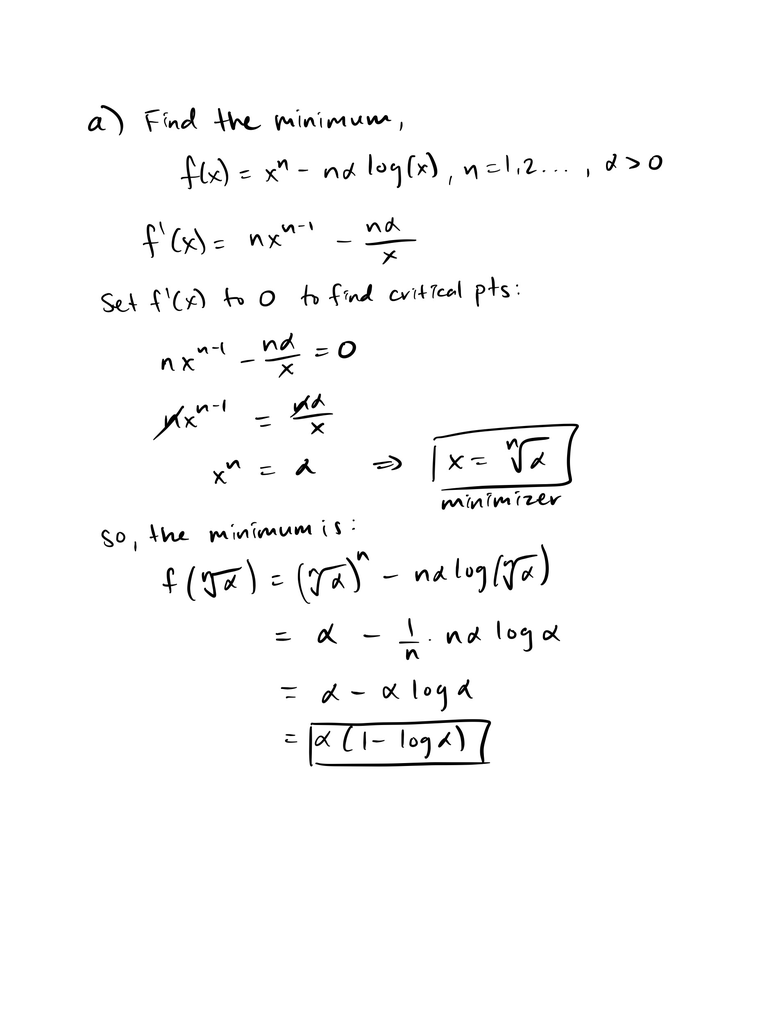

```r
knitr::include_graphics("part_a.jpg")
```

### (b)

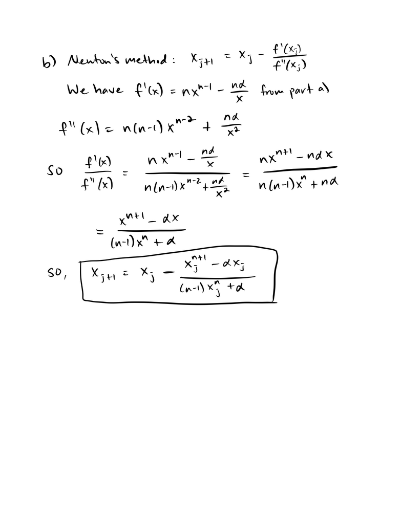

```r
knitr::include_graphics("part_b.jpg")
```

### (c)

#### **`get_min()`**

**Algorithm:**

1. Initialize the iteration count.
2. Define f’(x) by using D() in R.
3. Define f’’(x) by using D() again.
4. Now, run the Newton’s method for finding a critical point and per each iteration, have the iteration count increase by 1.
5. Return the “minimum value”.

```r
f <- expression(x^n - n*a*log(x))
get_min(f,1,n = 2,a = 3,tol = 10^-8)
```

```
## [1] -0.2958369
```

### (d)

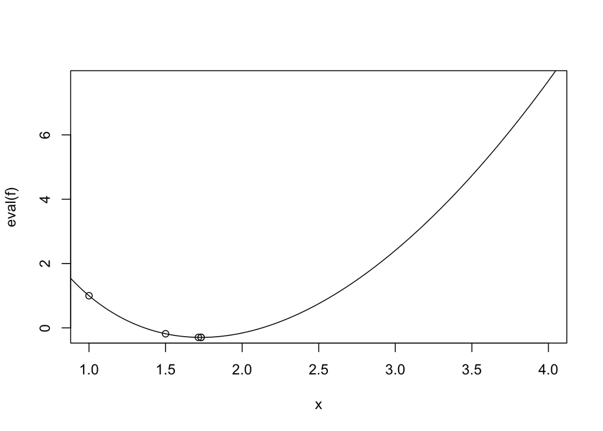

```r
x <- 1:4
n <- 2
a <- 3
plot(x, eval(f), type="n") # no points are plotted yet
x <- c(1, 1.5, 1.714286, 1.731959, 1.732051)  # these numbers are the iterative approximations (in order) of the minimizer
points(x, eval(f)) # plot points
x <- (50:450)/100
lines(x, eval(f))
```